# WRANGLE ACT ON WERATEDOGS DATA *BY AMOS OMOFAIYE*

## TABLE OF CONTENTS

1. Introduction of the project
2. Objectives of the project
3. Gathering data
4. Assessing the gathered data
5. Cleaning the assessed data
6. Storing the cleaned data
7. Analyzing and Visualizing the stored data
8. Limitations of the analysis
9. Conclusions from the analysis and visualizations
10. Bibliograpphy

## INTRODUCTION OF THE PROJECT

> This project is part of the Bertelsman Scholarship for Data Analyst from Udacity. The main thrust is to analyze tweet data of **WeRateDogs** - a dog rating organization. This organization provides a humourous dog rating service. One notable thing is that their rating numerator is usually greater than the denominator. This is akin to awarding a student 12/10. They do this because the dog is too good to them. Other information about them can be found in the README.txt file. To begin with, the data must first be gathered from three sources. One of the files has been provided by Udacity (*twitter-archive-enhanced.csv*). The second dataset will be programmatically gathered from udacity through the address (https://d17h27t6h515a5.cloudfront.net/topher/2017/August/599fd2ad_image-predictions/image-predictions.tsv). This second dataset will be stored as **image-predictions.tsv** which is the file name. The third and the final dataset for this project will be programmatically gathered from twitter using their API. The data will be stored as **tweet-json.txt** and the needed data will be ectracted from it into a dataframe. After gathering the data will be cleaned, combined, stored, analyzed, visualized, and reported on. I will try to make the process as interactive as possible. Now, we look at the specific objectives of the project.

## Objectives of the project

> The objectives of the project are to:
> - gather data from three different sources.
> - assess the gathered data with the aim of identifying at least 8 quality issues and 2 tidiness issues.
> - clean the data with respect to the identified issues.
> - store the cleaned data in a file titled **twitter-archive-master.csv**.
> - analyze and visualize the stored data producing at least 3 insights and 1 visualization.
> - report the work by producing two documents namely internal (wrangle_report.pdf or html with 300-600 words) detailing the wrangling efforts and external (act_report.pdf or html, 250 words mininum) detailing the insights and visualizations.

## Gathering data

>

> Now the main work begins. In this section I will gather the needed datasets. To do this I will need the following libraries *requests, tweepy, json, pandas, and numpy*. I will also import the libraries that I will later use for visualization. These will be *matplotlib, seaborn, and pywaffle*. Please note that because it took a long time before my twitter api application was approved, I used the tweet-json.txt file provided as an alternative. But I later got the api. I d not deem it necessary to redo the sesion again because when I extracted the data it was the same except that it took longer than 1hour 30 minutes before I could finish the download. Let us continue.

```python
# Importing the needed libraries
import requests as rs
import numpy as np
import pandas as pd
import seaborn as sb
import matplotlib.pyplot as plt
from pywaffle import Waffle
import tweepy
import json
```

```python
# Programmatically downloading the image-predictions.tsv using the requests library
url = 'https://d17h27t6h515a5.cloudfront.net/topher/2017/August/599fd2ad_image-predictions/image-predictions.tsv'
response = rs.get(url)
with open("image-predictions.tsv", mode="wb") as file:
    file.write(response.content)
```

```python
# Loading the image-predictions dataset. Since it is a tsv, I had to use tab as the separator.
di = pd.read_csv('image-predictions.tsv', sep='\t')
```

```python
# Checking to see whether it is correctly loaded. Note that di means dataframe of image predictions
di.head()
```

|  | tweet_id | jpg_url | img_num | p1 | p1_conf | p1_dog | p2 | p2_conf | p2_dog | p3 | p3_conf | p3_dog |
| --- | --- | --- | --- | --- | --- | --- | --- | --- | --- | --- | --- | --- |
| 0 | 666020888022790149 | https://pbs.twimg.com/media/CT4udn0WwAA0aMy.jpg | 1 | Welsh_springer_spaniel | 0.465074 | True | collie | 0.156665 | True | Shetland_sheepdog | 0.061428 | True |
| 1 | 666029285002620928 | https://pbs.twimg.com/media/CT42GRgUYAA5iDo.jpg | 1 | redbone | 0.506826 | True | miniature_pinscher | 0.074192 | True | Rhodesian_ridgeback | 0.072010 | True |
| 2 | 666033412701032449 | https://pbs.twimg.com/media/CT4521TWwAEvMyu.jpg | 1 | German_shepherd | 0.596461 | True | malinois | 0.138584 | True | bloodhound | 0.116197 | True |
| 3 | 666044226329800704 | https://pbs.twimg.com/media/CT5Dr8HUEAA-lEu.jpg | 1 | Rhodesian_ridgeback | 0.408143 | True | redbone | 0.360687 | True | miniature_pinscher | 0.222752 | True |
| 4 | 666049248165822465 | https://pbs.twimg.com/media/CT5IQmsXIAAKY4A.jpg | 1 | miniature_pinscher | 0.560311 | True | Rottweiler | 0.243682 | True | Doberman | 0.154629 | True |

```python
# Loading the given twitter archive enhanced file into a dataframe.
dt = pd.read_csv('twitter-archive-enhanced.csv')
```

```python
# Checking to see whether it is correctly loaded. Note that dt means dataframe of twitter archive enhanced
dt.head()
```

|  | tweet_id | in_reply_to_status_id | in_reply_to_user_id | timestamp | source | text | retweeted_status_id | retweeted_status_user_id | retweeted_status_timestamp | expanded_urls | rating_numerator | rating_denominator | name | doggo | floofer | pupper | puppo |
| --- | --- | --- | --- | --- | --- | --- | --- | --- | --- | --- | --- | --- | --- | --- | --- | --- | --- |
| 0 | 892420643555336193 | NaN | NaN | 2017-08-01 16:23:56 +0000 | <a href="http://twitter.com/download/iphone" r... | This is Phineas. He's a mystical boy. Only eve... | NaN | NaN | NaN | https://twitter.com/dog_rates/status/892420643... | 13 | 10 | Phineas | None | None | None | None |
| 1 | 892177421306343426 | NaN | NaN | 2017-08-01 00:17:27 +0000 | <a href="http://twitter.com/download/iphone" r... | This is Tilly. She's just checking pup on you.... | NaN | NaN | NaN | https://twitter.com/dog_rates/status/892177421... | 13 | 10 | Tilly | None | None | None | None |
| 2 | 891815181378084864 | NaN | NaN | 2017-07-31 00:18:03 +0000 | <a href="http://twitter.com/download/iphone" r... | This is Archie. He is a rare Norwegian Pouncin... | NaN | NaN | NaN | https://twitter.com/dog_rates/status/891815181... | 12 | 10 | Archie | None | None | None | None |
| 3 | 891689557279858688 | NaN | NaN | 2017-07-30 15:58:51 +0000 | <a href="http://twitter.com/download/iphone" r... | This is Darla. She commenced a snooze mid meal... | NaN | NaN | NaN | https://twitter.com/dog_rates/status/891689557... | 13 | 10 | Darla | None | None | None | None |
| 4 | 891327558926688256 | NaN | NaN | 2017-07-29 16:00:24 +0000 | <a href="http://twitter.com/download/iphone" r... | This is Franklin. He would like you to stop ca... | NaN | NaN | NaN | https://twitter.com/dog_rates/status/891327558... | 12 | 10 | Franklin | None | None | None | None |

# The copied code due to lack of access to twitter API is in this cell. It will not be run

# Query Twitter API for each tweet in the Twitter archive and save JSON in a text file

# These are hidden to comply with Twitter's API terms and conditions

api = tweepy.API(auth, wait_on_rate_limit=True)

# NOTE TO STUDENT WITH MOBILE VERIFICATION ISSUES:

# df_1 is a DataFrame with the twitter_archive_enhanced.csv file. You may have to

# change line 17 to match the name of your DataFrame with twitter_archive_enhanced.csv

# NOTE TO REVIEWER: this student had mobile verification issues so the following

# Twitter API code was sent to this student from a Udacity instructor

# Tweet IDs for which to gather additional data via Twitter's API

# Query Twitter's API for JSON data for each tweet ID in the Twitter archive

# Save each tweet's returned JSON as a new line in a .txt file

with open('tweet_json.txt', 'w') as outfile:

```
# This loop will likely take 20-30 minutes to run because of Twitter's rate limit
for tweet_id in tweet_ids:
    count += 1
    print(str(count) + ": " + str(tweet_id))
    try:
        tweet = api.get_status(tweet_id, tweet_mode='extended')
        print("Success")
        json.dump(tweet._json, outfile)
        outfile.write('\n')
    except tweepy.TweepError as e:
        print("Fail")
        fails_dict[tweet_id] = e
        pass
```

```python
# Creating a list of data from the available tweet-json.txt file
tweets_data = []
tweet_file = open('tweet-json.txt', 'r')
for line in tweet_file:
    try:
        tweet = json.loads(line)
        tweets_data.append(tweet)
    except:
        continue
tweet_file.close()
```

```python
# Checking the list to determine which columns that I will like to include apart from the compulsory
# tweet id, retweet count, and favorite count.
#tweets_data
```

```python
# Creating a  dataframe for  the extracted tweet information. The dataframe will be named dj.
dj = pd.DataFrame()
# Add variables to df: tweet ID, retweet count, favorite count
dj['tweet_id'] = list(map(lambda tweet: tweet['id'], tweets_data))
dj['created_at'] = list(map(lambda tweet: tweet['created_at'], tweets_data))
dj['retweet_count'] = list(map(lambda tweet: tweet['retweet_count'], tweets_data))
dj['favorite_count'] = list(map(lambda tweet: tweet['favorite_count'], tweets_data))
dj['full_text'] = list(map(lambda tweet: tweet['full_text'], tweets_data))
dj['full_text'] = list(map(lambda tweet: tweet['full_text'], tweets_data))
dj['favorited'] = list(map(lambda tweet: tweet['favorited'], tweets_data))
dj['retweeted'] = list(map(lambda tweet: tweet['retweeted'], tweets_data))
```

```python
# Checking to see how the dataframe looks. Note that dj means dataframe of extracted data from the tweet-json.txt file.
dj.head()
```

|  | tweet_id | created_at | retweet_count | favorite_count | full_text | favorited | retweeted |
| --- | --- | --- | --- | --- | --- | --- | --- |
| 0 | 892420643555336193 | Tue Aug 01 16:23:56 +0000 2017 | 8853 | 39467 | This is Phineas. He's a mystical boy. Only eve... | False | False |
| 1 | 892177421306343426 | Tue Aug 01 00:17:27 +0000 2017 | 6514 | 33819 | This is Tilly. She's just checking pup on you.... | False | False |
| 2 | 891815181378084864 | Mon Jul 31 00:18:03 +0000 2017 | 4328 | 25461 | This is Archie. He is a rare Norwegian Pouncin... | False | False |
| 3 | 891689557279858688 | Sun Jul 30 15:58:51 +0000 2017 | 8964 | 42908 | This is Darla. She commenced a snooze mid meal... | False | False |
| 4 | 891327558926688256 | Sat Jul 29 16:00:24 +0000 2017 | 9774 | 41048 | This is Franklin. He would like you to stop ca... | False | False |

```python
# Saving the dj dataframe to csv file
#dj.to_csv('tweet_extract.csv', index=False)
```

```python
# Generating requirements.txt file for this project
#!pip freeze > requirements.txt
```

## Assessing the gathered data

>

> In this section I will assess the three datasets with the aim of identifying at least 8 data quality issues and 2 data tidiness issues.

> Data Quality issues will include such things as missing values, non-descriptive column headings, duplications, incorrect spellings etc. Generally, they may be categorized into issues of that undermine data *completeness, uniqueness, timeliness, validity, accuracy, and consistency*. Datasets with such issues are called **dirty datasets**.

> Data tidiness issues are seen in datasets that do not follow the tidy data principle. Such datasets are called **messy datasets**. Please note that a tidy dataset should have each variable forming a column, each observation forming a row, and each type of observational unit forming a table.

> With that preamble we delve into the assessment process. I shall assess the data in the following order: dj, dt, and di. Shall we?

```python
# Assesing the shape of the data extracted from tweet-json.txt. This is stored in the dj dataframe.
dj.shape
```

```
(2354, 7)
```

```python
# Viewing some samples of the dataframe
dj.sample(5)
```

|  | tweet_id | created_at | retweet_count | favorite_count | full_text | favorited | retweeted |
| --- | --- | --- | --- | --- | --- | --- | --- |
| 820 | 770093767776997377 | Mon Aug 29 03:00:36 +0000 2016 | 3520 | 0 | RT @dog_rates: This is just downright precious... | False | False |
| 211 | 851861385021730816 | Tue Apr 11 18:15:55 +0000 2017 | 23 | 0 | RT @eddie_coe98: Thanks @dog_rates completed m... | False | False |
| 1619 | 684926975086034944 | Thu Jan 07 02:38:10 +0000 2016 | 552 | 3849 | Meet Bruiser &amp; Charlie. They are the best ... | False | False |
| 499 | 813112105746448384 | Sun Dec 25 20:00:07 +0000 2016 | 3225 | 11515 | Meet Toby. He's pupset because his hat isn't b... | False | False |
| 167 | 859607811541651456 | Wed May 03 03:17:27 +0000 2017 | 1704 | 19476 | Sorry for the lack of posts today. I came home... | False | False |

```python
# Listing out its columns
# First, I will define a function to do this so that I call the function on any dataframe.
def column_lister(df):
    """
    This function will take a single argument. The argument must hold a dataframe with columns.
    The function will then return a borderless table showing the columns in the dataframe with their indices.
    """
    for i,v in enumerate(df.columns):
        print(i,v)
column_lister(dj)
```

```
0 tweet_id
1 created_at
2 retweet_count
3 favorite_count
4 full_text
5 favorited
6 retweeted
```

### twitter_json(dj) dataframe columns

> First let me explain these columns in brief.
> - tweet_id is the number that identifies each tweet. Customarily, it shhould be unique that is without duplicates.
> - created_at shows the time the tweet was created. Since I will not expect an organization to create two tweets at a time, then the this column should contain unique values.
> - retweet_count is the number of times the tweet was retweeted by users.
> - favorite_count is the number of times the tweet was declared a favorite by users.
> - full_text is the message or the text of the tweet.
> - favorited answers the question whether the tweet was favorited or not by WeRateDogs. It should be either False or True.
> - retweeted answers the question whether the tweet was retweeted or not by WeRateDogs. It should be either False or True.

```python
# I want to check the tweet_id for uniqueness since it will be needed in joining the three data sets. To be useful for joinig it
# must be uniquely present in all the three dataframes.
dj.tweet_id.unique().size, dj.tweet_id.nunique()
```

```
(2354, 2354)
```

> The dj dataframe contains 2354 rows and 7 columns. The tweet_id column as shown by the two methods above contains unique values and can therefore be used in joining the datasets. Let us continue.

```python
# Checking for null values
dj.info()
```

```
<class 'pandas.core.frame.DataFrame'>
RangeIndex: 2354 entries, 0 to 2353
Data columns (total 7 columns):
 #   Column          Non-Null Count  Dtype
---  ------          --------------  -----
 0   tweet_id        2354 non-null   int64
 1   created_at      2354 non-null   object
 2   retweet_count   2354 non-null   int64
 3   favorite_count  2354 non-null   int64
 4   full_text       2354 non-null   object
 5   favorited       2354 non-null   bool
 6   retweeted       2354 non-null   bool
dtypes: bool(2), int64(3), object(2)
memory usage: 96.7+ KB
```

```python
# Checking for duplicates
sum(dj.duplicated())
```

```
0
```

```python
# Checking for data types
dj.dtypes
```

```
tweet_id           int64
created_at        object
retweet_count      int64
favorite_count     int64
full_text         object
favorited           bool
retweeted           bool
dtype: object
```

```python
# Describing the quantitative variables in this dataframe
dj.describe()
```

|  | tweet_id | retweet_count | favorite_count |
| --- | --- | --- | --- |
| count | 2.354000e+03 | 2354.000000 | 2354.000000 |
| mean | 7.426978e+17 | 3164.797366 | 8080.968564 |
| std | 6.852812e+16 | 5284.770364 | 11814.771334 |
| min | 6.660209e+17 | 0.000000 | 0.000000 |
| 25% | 6.783975e+17 | 624.500000 | 1415.000000 |
| 50% | 7.194596e+17 | 1473.500000 | 3603.500000 |
| 75% | 7.993058e+17 | 3652.000000 | 10122.250000 |
| max | 8.924206e+17 | 79515.000000 | 132810.000000 |

```python
# Checking the observations that are above the 75th percentile
dj[dj['retweet_count'] > 3652].shape, dj[dj['favorite_count'] > 10122.25].shape
# Although there appears to be great difference, the difference warants further investigation to determine outliers.
```

```
((586, 7), (589, 7))
```

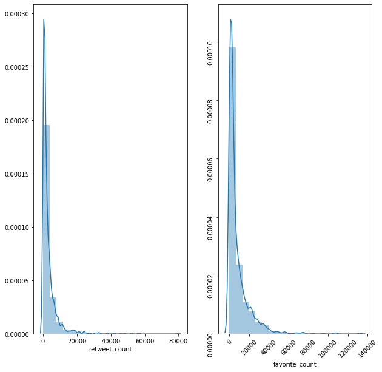

```python
# Visualizing the distribution of retweet_count and favorite_count
plt.figure(figsize=(10,10))
plt.subplot(1,2,1)
sb.distplot(dj['retweet_count'], bins = 20)
plt.subplot(1,2,2)
sb.distplot(dj['favorite_count'], bins = 20)
plt.yticks(rotation=90)
plt.xticks(rotation=45);
```

> The distribution of the retweet_count and the favorite_count are positively skewed with a few outliers. Let us continue.

```python
# Checking for variation in some columns
# dj.created_at.value_counts() # Varies and all values are unique
# dj.retweet_count.value_counts() # Varies with maximum being 5 and one tweet having zero retweet
# dj.favorite_count.value_counts() # Varies with 179 tweets having zero favorite
# dj.favorited.value_counts() # Varies but greatly tends towards False as only 8 tweets were favorited by WeRateDogs
# dj.retweeted.value_counts() # Does not vary. All values are False. No tweet was retweeted by WeRateDogs
```

### Next, we assess the twitter-archive-enhanced dataset. This is stored in dt dataframe.

```python
# Assesing the shape of the dt dataframe.
dt.shape
```

```
(2356, 17)
```

```python
# Viewing some samples of the dataframe
dt.sample(15,replace=False).T
```

|  | 1537 | 1917 | 127 | 2165 | 1721 | 367 | 456 | 905 | 1398 | 588 | 2292 | 2181 | 2062 | 1418 | 1628 |
| --- | --- | --- | --- | --- | --- | --- | --- | --- | --- | --- | --- | --- | --- | --- | --- |
| tweet_id | 689877686181715968 | 674291837063053312 | 867900495410671616 | 669367896104181761 | 680130881361686529 | 828770345708580865 | 818259473185828864 | 758099635764359168 | 699775878809702401 | 799422933579902976 | 667160273090932737 | 668994913074286592 | 671163268581498880 | 698355670425473025 | 684588130326986752 |
| in_reply_to_status_id | NaN | NaN | NaN | NaN | NaN | NaN | NaN | NaN | NaN | NaN | NaN | NaN | NaN | NaN | NaN |
| in_reply_to_user_id | NaN | NaN | NaN | NaN | NaN | NaN | NaN | NaN | NaN | NaN | NaN | NaN | NaN | NaN | NaN |
| timestamp | 2016-01-20 18:30:32 +0000 | 2015-12-08 18:17:56 +0000 | 2017-05-26 00:29:37 +0000 | 2015-11-25 04:11:57 +0000 | 2015-12-24 21:00:12 +0000 | 2017-02-07 01:00:22 +0000 | 2017-01-09 00:53:55 +0000 | 2016-07-27 00:40:12 +0000 | 2016-02-17 02:02:25 +0000 | 2016-11-18 01:24:14 +0000 | 2015-11-19 01:59:39 +0000 | 2015-11-24 03:29:51 +0000 | 2015-11-30 03:06:07 +0000 | 2016-02-13 03:59:01 +0000 | 2016-01-06 04:11:43 +0000 |
| source | <a href="http://twitter.com/download/iphone" r... | <a href="http://twitter.com/download/iphone" r... | <a href="http://twitter.com/download/iphone" r... | <a href="http://twitter.com/download/iphone" r... | <a href="http://twitter.com/download/iphone" r... | <a href="http://twitter.com/download/iphone" r... | <a href="http://twitter.com/download/iphone" r... | <a href="http://vine.co" rel="nofollow">Vine -... | <a href="http://twitter.com/download/iphone" r... | <a href="http://twitter.com/download/iphone" r... | <a href="http://twitter.com/download/iphone" r... | <a href="http://twitter.com/download/iphone" r... | <a href="http://twitter.com/download/iphone" r... | <a href="http://twitter.com/download/iphone" r... | <a href="http://vine.co" rel="nofollow">Vine -... |
| text | This is Durg. He's trying to conquer his fear ... | This is Kenny. He just wants to be included in... | Unbelievable. We only rate dogs. Please don't ... | This is Chip. Chip's pretending to be choked. ... | This is Reggie. His Santa hat is a little big.... | This is Alfie. He's your Lyft for tonight. Kin... | This is Florence. He saw the same snap you sen... | In case you haven't seen the most dramatic sne... | Meet Fillup. Spaghetti is his main weakness. A... | This is Longfellow (prolly sophisticated). He'... | This is Bradlay. He is a Ronaldinho Matsuyama ... | Two gorgeous pups here. Both have cute fake ho... | Pack of horned dogs here. Very team-oriented b... | This is Jessiga. She's a Tasmanian McCringlebe... | This pupper just got his first kiss. 12/10 he'... |
| retweeted_status_id | NaN | NaN | NaN | NaN | NaN | NaN | NaN | NaN | NaN | NaN | NaN | NaN | NaN | NaN | NaN |
| retweeted_status_user_id | NaN | NaN | NaN | NaN | NaN | NaN | NaN | NaN | NaN | NaN | NaN | NaN | NaN | NaN | NaN |
| retweeted_status_timestamp | NaN | NaN | NaN | NaN | NaN | NaN | NaN | NaN | NaN | NaN | NaN | NaN | NaN | NaN | NaN |
| expanded_urls | https://twitter.com/dog_rates/status/689877686... | https://twitter.com/dog_rates/status/674291837... | https://twitter.com/dog_rates/status/867900495... | https://twitter.com/dog_rates/status/669367896... | https://twitter.com/dog_rates/status/680130881... | https://twitter.com/dog_rates/status/828770345... | https://twitter.com/dog_rates/status/818259473... | https://vine.co/v/hQJbaj1VpIz | https://twitter.com/dog_rates/status/699775878... | https://twitter.com/dog_rates/status/799422933... | https://twitter.com/dog_rates/status/667160273... | https://twitter.com/dog_rates/status/668994913... | https://twitter.com/dog_rates/status/671163268... | https://twitter.com/dog_rates/status/698355670... | https://vine.co/v/ihWIxntjtO7 |
| rating_numerator | 9 | 11 | 12 | 10 | 10 | 13 | 12 | 13 | 11 | 12 | 11 | 5 | 8 | 10 | 12 |
| rating_denominator | 10 | 10 | 10 | 10 | 10 | 10 | 10 | 10 | 10 | 10 | 10 | 10 | 10 | 10 | 10 |
| name | Durg | Kenny | None | Chip | Reggie | Alfie | Florence | None | Fillup | Longfellow | Bradlay | None | None | Jessiga | None |
| doggo | None | None | None | None | None | None | None | None | None | None | None | None | None | None | None |
| floofer | None | None | None | None | None | None | None | None | None | None | None | None | None | None | None |
| pupper | None | None | None | None | None | None | None | None | None | None | None | None | None | None | pupper |
| puppo | None | None | None | None | None | None | None | None | None | None | None | None | None | None | None |

```python
# Listing out the columns of the dt dataframe
column_lister(dt)
```

```
0 tweet_id
1 in_reply_to_status_id
2 in_reply_to_user_id
3 timestamp
4 source
5 text
6 retweeted_status_id
7 retweeted_status_user_id
8 retweeted_status_timestamp
9 expanded_urls
10 rating_numerator
11 rating_denominator
12 name
13 doggo
14 floofer
15 pupper
16 puppo
```